# ANN Wine Quality Pipeline

```python
import numpy as np
import pandas as pd
import matplotlib.pyplot as plt
from joblib import Parallel, delayed
from sklearn.model_selection import train_test_split
from sklearn.neural_network import MLPRegressor

from ANN import ANNRegression
from utils import preprocessing as pp
from utils import normalization as nz
from utils import hp_search_grid as hp
from utils import calculate_metrics as cm
from utils import plot_residuals
```

## 1. Load and preprocess data

```python
red_file = "winequality-red.csv"
white_file = "winequality-white.csv"

X_train, y_train, X_test, y_test = pp(red_file, white_file)
normed_X_train, normed_X_test, scaler = nz(X_train, X_test)

y_train_np = y_train.to_numpy(dtype=np.float64).reshape(-1, 1)
y_test_np = y_test.to_numpy(dtype=np.float64).reshape(-1, 1)

print("Train shape:", normed_X_train.shape, y_train_np.shape)
print("Test shape:", normed_X_test.shape, y_test_np.shape)
```

```
       fixed acidity  volatile acidity  citric acid  residual sugar  \
count    6497.000000       6497.000000  6497.000000     6497.000000
mean        7.215307          0.339666     0.318633        5.443235
std         1.296434          0.164636     0.145318        4.757804
min         3.800000          0.080000     0.000000        0.600000
25%         6.400000          0.230000     0.250000        1.800000
50%         7.000000          0.290000     0.310000        3.000000
75%         7.700000          0.400000     0.390000        8.100000
max        15.900000          1.580000     1.660000       65.800000

         chlorides  free sulfur dioxide  total sulfur dioxide      density  \
count  6497.000000          6497.000000           6497.000000  6497.000000
mean      0.056034            30.525319            115.744574     0.994697
std       0.035034            17.749400             56.521855     0.002999
min       0.009000             1.000000              6.000000     0.987110
25%       0.038000            17.000000             77.000000     0.992340
50%       0.047000            29.000000            118.000000     0.994890
75%       0.065000            41.000000            156.000000     0.996990
max       0.611000           289.000000            440.000000     1.038980

                pH    sulphates      alcohol          red      quality
count  6497.000000  6497.000000  6497.000000  6497.000000  6497.000000
mean      3.218501     0.531268    10.491801     0.246114     5.818378
std       0.160787     0.148806     1.192712     0.430779     0.873255
min       2.720000     0.220000     8.000000     0.000000     3.000000
25%       3.110000     0.430000     9.500000     0.000000     5.000000
50%       3.210000     0.510000    10.300000     0.000000     6.000000
75%       3.320000     0.600000    11.300000     0.000000     6.000000
max       4.010000     2.000000    14.900000     1.000000     9.000000
fixed acidity           0
volatile acidity        0
citric acid             0
residual sugar          0
chlorides               0
free sulfur dioxide     0
total sulfur dioxide    0
density                 0
pH                      0
sulphates               0
alcohol                 0
red                     0
quality                 0
dtype: int64
red
0    4898
1    1599
Name: count, dtype: int64
Train shape: (5197, 12) (5197, 1)
Test shape: (1300, 12) (1300, 1)
```

## 2. Architecture from `utils.py`

```python
ann_grid = hp("ann", y_train)
ann_grid
```

```
{'hidden_widths': [8, 16, 32, 64],
 'architectures': [[8],
  [16],
  [32],
  [64],
  [16, 8],
  [32, 16],
  [64, 16],
  [64, 32]]}
```

## 3. Experiment design and model sweep

This section fixes one shortlist of ANN architectures and then evaluates that same shortlist under three major activation-function batches: ReLU, tanh, and sigmoid.

### 3.1 Shared architecture family and hyperparameter ranges

Every batch below uses the same 8 ANN architectures from `utils.py`. The input layer always has 12 nodes because the wine dataset has 12 features after preprocessing, and the output layer always has 1 linear node because this is a regression problem.

Selected architectures and why they are included:

- `12 -> 8 -> 1`: smallest nonlinear model; checks whether a very compact network is already enough.
- `12 -> 16 -> 1`: strong default shallow network; adds moderate capacity without becoming large.
- `12 -> 32 -> 1`: tests whether a wider shallow model improves over 8 or 16 units.
- `12 -> 64 -> 1`: upper bound for shallow width; useful for checking whether more width actually helps.
- `12 -> 16 -> 8 -> 1`: smallest tapered deep model; tests whether depth helps beyond a small 1-layer ANN.
- `12 -> 32 -> 16 -> 1`: strongest medium-sized tapered 2-layer candidate; balances expressiveness and control.
- `12 -> 64 -> 16 -> 1`: tests a wide first hidden layer followed by compression into a bottleneck.
- `12 -> 64 -> 32 -> 1`: strongest larger 2-layer candidate worth keeping before the model class becomes unnecessarily large.

Why the four hidden-layer sizes `8`, `16`, `32`, and `64` were chosen:

- they provide a clean progression from small to moderately wide networks
- they are enough to test under-capacity, reasonable capacity, and mild over-capacity on a 12-feature dataset
- they keep the search interpretable and computationally manageable

Why smaller sizes were not emphasized:

- widths below `8` would likely be too restrictive for modeling nonlinear structure in this dataset
- very small widths are less informative because they behave more like severe bottlenecks than realistic ANN candidates

Learning-rate values tested: `1e-4`, `5e-4`, `1e-3`, `5e-3`

- `1e-4` checks whether training needs a conservative step size for stable optimization
- `5e-4` and `1e-3` cover reasonable middle-ground values for this scale of tabular regression problem
- `5e-3` tests whether the network benefits from more aggressive optimization or becomes unstable

L2 values tested: `0`, `1e-5`, `1e-4`, `1e-3`

- `0` gives an unregularized baseline
- `1e-5` tests very light regularization
- `1e-4` is a moderate default regularization strength
- `1e-3` checks whether stronger shrinkage improves generalization for wider models

Epoch values tested: `2000` and `5000`

- `2000` is a moderate training budget
- `5000` checks whether additional training materially improves the fit

```python
input_dim = normed_X_train.shape[1]
output_dim = 1
hidden_widths = ann_grid["hidden_widths"]
architecture_list = ann_grid["architectures"]

def format_architecture(hidden_layers):
    return " -> ".join(map(str, [input_dim] + list(hidden_layers) + [output_dim]))

architectures_df = pd.DataFrame(
    [
        {
            "num_hidden_layers": len(hidden_layers),
            "hidden_layers": hidden_layers,
            "architecture": format_architecture(hidden_layers),
        }
        for hidden_layers in architecture_list
    ]
)
architectures_df
```

|  | num_hidden_layers | hidden_layers | architecture |
| --- | --- | --- | --- |
| 0 | 1 | [8] | 12 -> 8 -> 1 |
| 1 | 1 | [16] | 12 -> 16 -> 1 |
| 2 | 1 | [32] | 12 -> 32 -> 1 |
| 3 | 1 | [64] | 12 -> 64 -> 1 |
| 4 | 2 | [16, 8] | 12 -> 16 -> 8 -> 1 |
| 5 | 2 | [32, 16] | 12 -> 32 -> 16 -> 1 |
| 6 | 2 | [64, 16] | 12 -> 64 -> 16 -> 1 |
| 7 | 2 | [64, 32] | 12 -> 64 -> 32 -> 1 |

### 3.2 ReLU batch

This batch evaluates every selected architecture over the full learning-rate, L2, and epoch grid using ReLU hidden units.

### 3.3 Tanh batch

This batch repeats the same architecture and hyperparameter sweep with tanh hidden units so the effect of activation choice can be compared directly.

### 3.4 Sigmoid batch

This batch repeats the same architecture and hyperparameter sweep with sigmoid hidden units, even though sigmoid is often weaker in deeper settings, so the comparison study remains complete.

```python
activation_batches = [
    {
        "subsection": "3.2",
        "batch_name": "relu_batch",
        "activation": "relu",
        "description": "Full hyperparameter sweep with ReLU hidden units.",
    },
    {
        "subsection": "3.3",
        "batch_name": "tanh_batch",
        "activation": "tanh",
        "description": "Full hyperparameter sweep with tanh hidden units.",
    },
    {
        "subsection": "3.4",
        "batch_name": "sigmoid_batch",
        "activation": "sigmoid",
        "description": "Full hyperparameter sweep with sigmoid hidden units.",
    },
]

learning_rates = [1e-4, 5e-4, 1e-3, 5e-3]
l2_coeffs = [0.0, 1e-5, 1e-4, 1e-3]
max_epochs_values = [2000, 5000]

batch_df = pd.DataFrame(activation_batches)
grid_df = pd.DataFrame(
    [
        {
            "learning_rate": lr,
            "l2_coeff": l2,
            "max_epochs": epochs,
        }
        for lr in learning_rates
        for l2 in l2_coeffs
        for epochs in max_epochs_values
    ]
)

print("Architectures:", len(architecture_list))
print("Activation batches:", len(activation_batches))
print("Hyperparameter combinations per batch:", len(grid_df))
print("Total ANN runs:", len(architecture_list) * len(activation_batches) * len(grid_df))

batch_df
```

```
Architectures: 8
Activation batches: 3
Hyperparameter combinations per batch: 32
Total ANN runs: 768
```

|  | subsection | batch_name | activation | description |
| --- | --- | --- | --- | --- |
| 0 | 3.2 | relu_batch | relu | Full hyperparameter sweep with ReLU hidden units. |
| 1 | 3.3 | tanh_batch | tanh | Full hyperparameter sweep with tanh hidden units. |
| 2 | 3.4 | sigmoid_batch | sigmoid | Full hyperparameter sweep with sigmoid hidden ... |

```python
grid_df.head(12)
```

|  | learning_rate | l2_coeff | max_epochs |
| --- | --- | --- | --- |
| 0 | 0.0001 | 0.00000 | 2000 |
| 1 | 0.0001 | 0.00000 | 5000 |
| 2 | 0.0001 | 0.00001 | 2000 |
| 3 | 0.0001 | 0.00001 | 5000 |
| 4 | 0.0001 | 0.00010 | 2000 |
| 5 | 0.0001 | 0.00010 | 5000 |
| 6 | 0.0001 | 0.00100 | 2000 |
| 7 | 0.0001 | 0.00100 | 5000 |
| 8 | 0.0005 | 0.00000 | 2000 |
| 9 | 0.0005 | 0.00000 | 5000 |
| 10 | 0.0005 | 0.00001 | 2000 |
| 11 | 0.0005 | 0.00001 | 5000 |

### 3.5 Train models and compare results

Each activation batch is trained across the same 8 architectures and the same learning-rate, L2, and epoch grid. The cell below stores every run in `results`, builds a sortable summary table in `results_df`, and also creates `batch_best_df`, which keeps the best architecture and hyperparameter setting found within each activation batch.

```python
def run_ann_experiment(batch, hidden_layers, learning_rate, l2_coeff, max_epochs):
    architecture_label = format_architecture(hidden_layers)
    model = ANNRegression(
        num_layers=len(hidden_layers),
        num_units=hidden_layers,
        activation=batch["activation"],
        learning_rate=learning_rate,
        max_epochs=max_epochs,
        l2_coeff=l2_coeff,
        random_state=42,
    )

    if l2_coeff > 0:
        model.fit_with_l2_regularization(normed_X_train, y_train_np)
    else:
        model.fit(normed_X_train, y_train_np)

    test_pred = model.predict(normed_X_test).ravel()
    mse, rmse, mae, r2, acc1 = cm(y_test, test_pred)

    return {
        "subsection": batch["subsection"],
        "batch_name": batch["batch_name"],
        "description": batch["description"],
        "activation": batch["activation"],
        "learning_rate": learning_rate,
        "max_epochs": max_epochs,
        "l2_coeff": l2_coeff,
        "num_hidden_layers": len(hidden_layers),
        "hidden_layers": list(hidden_layers),
        "architecture": architecture_label,
        "mse": mse,
        "rmse": rmse,
        "mae": mae,
        "r2": r2,
        "acc1": acc1,
        "loss_history": model.loss_history,
        "model": model,
        "y_pred": test_pred,
    }

tasks = [
    (batch, hidden_layers, learning_rate, l2_coeff, max_epochs)
    for batch in activation_batches
    for hidden_layers in architecture_list
    for learning_rate in learning_rates
    for l2_coeff in l2_coeffs
    for max_epochs in max_epochs_values
]

results = Parallel(n_jobs=-2, verbose=10)(
    delayed(run_ann_experiment)(batch, hidden_layers, learning_rate, l2_coeff, max_epochs)
    for batch, hidden_layers, learning_rate, l2_coeff, max_epochs in tasks
)

best_record = min(results, key=lambda record: (record["mse"], record["rmse"]))
best_mse = best_record["mse"]

results_df = pd.DataFrame(
    [
        {
            "subsection": r["subsection"],
            "batch_name": r["batch_name"],
            "activation": r["activation"],
            "learning_rate": r["learning_rate"],
            "max_epochs": r["max_epochs"],
            "l2_coeff": r["l2_coeff"],
            "num_hidden_layers": r["num_hidden_layers"],
            "hidden_layers": r["hidden_layers"],
            "architecture": r["architecture"],
            "mse": r["mse"],
            "rmse": r["rmse"],
            "mae": r["mae"],
            "r2": r["r2"],
            "acc1": r["acc1"],
        }
        for r in results
    ]
).sort_values(["mse", "rmse"], ascending=[True, True]).reset_index(drop=True)

batch_best_df = (
    results_df.sort_values(["batch_name", "mse", "rmse"], ascending=[True, True, True])
    .groupby("batch_name", as_index=False)
    .first()
    .sort_values(["mse", "rmse"], ascending=[True, True])
    .reset_index(drop=True)
)

batch_best_df
```

```
[Parallel(n_jobs=-2)]: Using backend LokyBackend with 15 concurrent workers.
[Parallel(n_jobs=-2)]: Done   2 tasks      | elapsed:    7.3s
[Parallel(n_jobs=-2)]: Done  11 tasks      | elapsed:   10.9s
[Parallel(n_jobs=-2)]: Done  20 tasks      | elapsed:   13.0s
[Parallel(n_jobs=-2)]: Done  31 tasks      | elapsed:   15.5s
[Parallel(n_jobs=-2)]: Done  42 tasks      | elapsed:   23.0s
[Parallel(n_jobs=-2)]: Done  55 tasks      | elapsed:   24.6s
[Parallel(n_jobs=-2)]: Done  68 tasks      | elapsed:   29.2s
[Parallel(n_jobs=-2)]: Done  83 tasks      | elapsed:   33.6s
[Parallel(n_jobs=-2)]: Done  98 tasks      | elapsed:   38.3s
[Parallel(n_jobs=-2)]: Done 115 tasks      | elapsed:   45.2s
[Parallel(n_jobs=-2)]: Done 132 tasks      | elapsed:   55.0s
[Parallel(n_jobs=-2)]: Done 151 tasks      | elapsed:   59.7s
[Parallel(n_jobs=-2)]: Done 170 tasks      | elapsed:  1.1min
[Parallel(n_jobs=-2)]: Done 191 tasks      | elapsed:  1.2min
[Parallel(n_jobs=-2)]: Done 212 tasks      | elapsed:  1.3min
[Parallel(n_jobs=-2)]: Done 235 tasks      | elapsed:  1.5min
[Parallel(n_jobs=-2)]: Done 258 tasks      | elapsed:  1.6min
[Parallel(n_jobs=-2)]: Done 283 tasks      | elapsed:  1.7min
[Parallel(n_jobs=-2)]: Done 308 tasks      | elapsed:  1.9min
[Parallel(n_jobs=-2)]: Done 335 tasks      | elapsed:  2.0min
[Parallel(n_jobs=-2)]: Done 362 tasks      | elapsed:  2.2min
[Parallel(n_jobs=-2)]: Done 391 tasks      | elapsed:  2.5min
[Parallel(n_jobs=-2)]: Done 420 tasks      | elapsed:  3.0min
[Parallel(n_jobs=-2)]: Done 451 tasks      | elapsed:  3.2min
[Parallel(n_jobs=-2)]: Done 482 tasks      | elapsed:  3.5min
[Parallel(n_jobs=-2)]: Done 515 tasks      | elapsed:  3.8min
[Parallel(n_jobs=-2)]: Done 548 tasks      | elapsed:  4.1min
[Parallel(n_jobs=-2)]: Done 583 tasks      | elapsed:  4.5min
[Parallel(n_jobs=-2)]: Done 618 tasks      | elapsed:  4.8min
[Parallel(n_jobs=-2)]: Done 655 tasks      | elapsed:  5.6min
[Parallel(n_jobs=-2)]: Done 692 tasks      | elapsed:  6.6min
[Parallel(n_jobs=-2)]: Done 731 tasks      | elapsed:  7.9min
[Parallel(n_jobs=-2)]: Done 768 out of 768 | elapsed: 10.4min finished
```

|  | batch_name | subsection | activation | learning_rate | max_epochs | l2_coeff | num_hidden_layers | hidden_layers | architecture | mse | rmse | mae | r2 | acc1 |
| --- | --- | --- | --- | --- | --- | --- | --- | --- | --- | --- | --- | --- | --- | --- |
| 0 | relu_batch | 3.2 | relu | 0.0005 | 2000 | 0.0000 | 2 | [64, 32] | 12 -> 64 -> 32 -> 1 | 0.468383 | 0.684385 | 0.522758 | 0.361781 | 0.962308 |
| 1 | tanh_batch | 3.3 | tanh | 0.0050 | 2000 | 0.0010 | 2 | [64, 32] | 12 -> 64 -> 32 -> 1 | 0.481567 | 0.693950 | 0.537556 | 0.343816 | 0.963846 |
| 2 | sigmoid_batch | 3.4 | sigmoid | 0.0010 | 2000 | 0.0001 | 2 | [64, 16] | 12 -> 64 -> 16 -> 1 | 0.482081 | 0.694320 | 0.532206 | 0.343117 | 0.961538 |

```python
results_df.head(20)
```

|  | subsection | batch_name | activation | learning_rate | max_epochs | l2_coeff | num_hidden_layers | hidden_layers | architecture | mse | rmse | mae | r2 | acc1 |
| --- | --- | --- | --- | --- | --- | --- | --- | --- | --- | --- | --- | --- | --- | --- |
| 0 | 3.2 | relu_batch | relu | 0.0005 | 2000 | 0.00000 | 2 | [64, 32] | 12 -> 64 -> 32 -> 1 | 0.468383 | 0.684385 | 0.522758 | 0.361781 | 0.962308 |
| 1 | 3.2 | relu_batch | relu | 0.0005 | 5000 | 0.00000 | 2 | [64, 32] | 12 -> 64 -> 32 -> 1 | 0.468383 | 0.684385 | 0.522758 | 0.361781 | 0.962308 |
| 2 | 3.2 | relu_batch | relu | 0.0005 | 2000 | 0.00010 | 2 | [64, 32] | 12 -> 64 -> 32 -> 1 | 0.468529 | 0.684491 | 0.522890 | 0.361583 | 0.960769 |
| 3 | 3.2 | relu_batch | relu | 0.0005 | 5000 | 0.00010 | 2 | [64, 32] | 12 -> 64 -> 32 -> 1 | 0.468529 | 0.684491 | 0.522890 | 0.361583 | 0.960769 |
| 4 | 3.2 | relu_batch | relu | 0.0001 | 2000 | 0.00100 | 2 | [64, 32] | 12 -> 64 -> 32 -> 1 | 0.468677 | 0.684600 | 0.526193 | 0.361380 | 0.965385 |
| 5 | 3.2 | relu_batch | relu | 0.0001 | 5000 | 0.00100 | 2 | [64, 32] | 12 -> 64 -> 32 -> 1 | 0.468677 | 0.684600 | 0.526193 | 0.361380 | 0.965385 |
| 6 | 3.2 | relu_batch | relu | 0.0001 | 2000 | 0.00000 | 2 | [64, 32] | 12 -> 64 -> 32 -> 1 | 0.468677 | 0.684600 | 0.526288 | 0.361380 | 0.966154 |
| 7 | 3.2 | relu_batch | relu | 0.0001 | 5000 | 0.00000 | 2 | [64, 32] | 12 -> 64 -> 32 -> 1 | 0.468677 | 0.684600 | 0.526288 | 0.361380 | 0.966154 |
| 8 | 3.2 | relu_batch | relu | 0.0001 | 2000 | 0.00010 | 2 | [64, 32] | 12 -> 64 -> 32 -> 1 | 0.468747 | 0.684651 | 0.526218 | 0.361285 | 0.966154 |
| 9 | 3.2 | relu_batch | relu | 0.0001 | 5000 | 0.00010 | 2 | [64, 32] | 12 -> 64 -> 32 -> 1 | 0.468747 | 0.684651 | 0.526218 | 0.361285 | 0.966154 |
| 10 | 3.2 | relu_batch | relu | 0.0005 | 2000 | 0.00100 | 2 | [64, 32] | 12 -> 64 -> 32 -> 1 | 0.468794 | 0.684686 | 0.522015 | 0.361220 | 0.963077 |
| 11 | 3.2 | relu_batch | relu | 0.0005 | 5000 | 0.00100 | 2 | [64, 32] | 12 -> 64 -> 32 -> 1 | 0.468794 | 0.684686 | 0.522015 | 0.361220 | 0.963077 |
| 12 | 3.2 | relu_batch | relu | 0.0005 | 2000 | 0.00001 | 2 | [64, 32] | 12 -> 64 -> 32 -> 1 | 0.468952 | 0.684801 | 0.523621 | 0.361005 | 0.963077 |
| 13 | 3.2 | relu_batch | relu | 0.0005 | 5000 | 0.00001 | 2 | [64, 32] | 12 -> 64 -> 32 -> 1 | 0.468952 | 0.684801 | 0.523621 | 0.361005 | 0.963077 |
| 14 | 3.2 | relu_batch | relu | 0.0001 | 2000 | 0.00001 | 2 | [64, 32] | 12 -> 64 -> 32 -> 1 | 0.470879 | 0.686206 | 0.527915 | 0.358380 | 0.965385 |
| 15 | 3.2 | relu_batch | relu | 0.0001 | 5000 | 0.00001 | 2 | [64, 32] | 12 -> 64 -> 32 -> 1 | 0.470879 | 0.686206 | 0.527915 | 0.358380 | 0.965385 |
| 16 | 3.2 | relu_batch | relu | 0.0050 | 2000 | 0.00010 | 2 | [32, 16] | 12 -> 32 -> 16 -> 1 | 0.474426 | 0.688786 | 0.534726 | 0.353546 | 0.961538 |
| 17 | 3.2 | relu_batch | relu | 0.0050 | 5000 | 0.00010 | 2 | [32, 16] | 12 -> 32 -> 16 -> 1 | 0.474426 | 0.688786 | 0.534726 | 0.353546 | 0.961538 |
| 18 | 3.2 | relu_batch | relu | 0.0005 | 2000 | 0.00010 | 2 | [64, 16] | 12 -> 64 -> 16 -> 1 | 0.474598 | 0.688911 | 0.532519 | 0.353312 | 0.961538 |
| 19 | 3.2 | relu_batch | relu | 0.0005 | 5000 | 0.00010 | 2 | [64, 16] | 12 -> 64 -> 16 -> 1 | 0.474598 | 0.688911 | 0.532519 | 0.353312 | 0.961538 |

## 4. Best configuration across all experiments

This summary now refers to the single best run found anywhere in the three activation batches from sections 3.2 to 3.4.

```python
best_summary = {
    "subsection": best_record["subsection"],
    "batch_name": best_record["batch_name"],
    "activation": best_record["activation"],
    "learning_rate": best_record["learning_rate"],
    "max_epochs": best_record["max_epochs"],
    "l2_coeff": best_record["l2_coeff"],
    "num_hidden_layers": best_record["num_hidden_layers"],
    "hidden_layers": best_record["hidden_layers"],
    "architecture": best_record["architecture"],
    "mse": best_record["mse"],
    "rmse": best_record["rmse"],
    "mae": best_record["mae"],
    "r2": best_record["r2"],
    "acc1": best_record["acc1"],
}
best_summary
```

```
{'subsection': '3.2',
 'batch_name': 'relu_batch',
 'activation': 'relu',
 'learning_rate': 0.0005,
 'max_epochs': 2000,
 'l2_coeff': 0.0,
 'num_hidden_layers': 2,
 'hidden_layers': [64, 32],
 'architecture': '12 -> 64 -> 32 -> 1',
 'mse': 0.4683825598807007,
 'rmse': 0.6843848039522069,
 'mae': 0.5227579234876367,
 'r2': 0.36178143863386414,
 'acc1': 0.9623076923076923}
```

## 5. Training objective for the best configuration

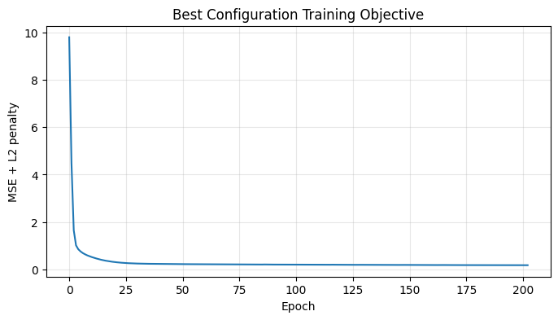

```python
plt.figure(figsize=(8, 4))
plt.plot(best_record["loss_history"])
plt.title("Best Configuration Training Objective")
plt.xlabel("Epoch")
plt.ylabel("MSE + L2 penalty")
plt.grid(True, alpha=0.3)
plt.show()
```

[output not shown]

[output cut: 351 more lines]

[output not shown]

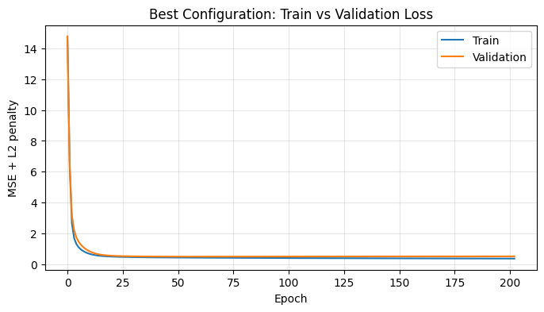

```python
X_inner_train, X_val, y_inner_train, y_val = train_test_split(
    normed_X_train,
    y_train_np,
    test_size=0.2,
    random_state=42,
)

def sklearn_activation_name(name):
    return "logistic" if name == "sigmoid" else name

def regularized_loss(model, X, y, l2_coeff):
    pred = model.predict(X).reshape(-1, 1)
    mse = float(np.mean((pred - y) ** 2))
    l2_penalty = 0.0
    if l2_coeff > 0:
        l2_penalty = sum(float(np.sum(coef ** 2)) for coef in model.coefs_)
    return mse + l2_coeff * l2_penalty

tracked_epochs = max(1, len(best_record["loss_history"]))

validation_probe = MLPRegressor(
    hidden_layer_sizes=tuple(best_record["hidden_layers"]),
    activation=sklearn_activation_name(best_record["activation"]),
    solver="adam",
    alpha=best_record["l2_coeff"],
    batch_size=128,
    learning_rate_init=best_record["learning_rate"],
    learning_rate="constant",
    max_iter=1,
    shuffle=True,
    random_state=42,
    tol=0.0,
    n_iter_no_change=tracked_epochs,
    early_stopping=False,
    warm_start=True,
)

train_loss_curve = []
val_loss_curve = []

for _ in range(tracked_epochs):
    validation_probe.fit(X_inner_train, y_inner_train.ravel())
    train_loss_curve.append(
        regularized_loss(validation_probe, X_inner_train, y_inner_train, best_record["l2_coeff"])
    )
    val_loss_curve.append(
        regularized_loss(validation_probe, X_val, y_val, best_record["l2_coeff"])
    )

plt.figure(figsize=(8, 4))
plt.plot(train_loss_curve, label="Train")
plt.plot(val_loss_curve, label="Validation")
plt.title("Best Configuration: Train vs Validation Loss")
plt.xlabel("Epoch")
plt.ylabel("MSE + L2 penalty")
plt.legend()
plt.grid(True, alpha=0.3)
plt.show()
```

## 7. Predicted vs actual quality for the best configuration

This scatter plot uses the best model found across all experiment batches.

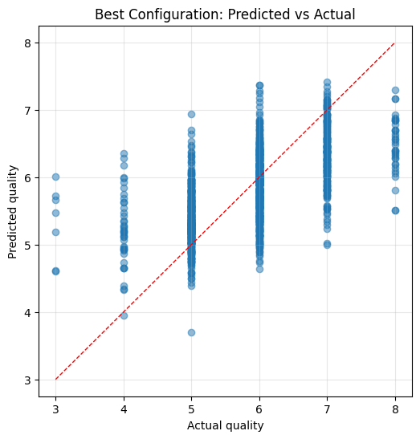

```python
plt.figure(figsize=(6, 6))
plt.scatter(y_test, best_record["y_pred"], alpha=0.5)
plt.xlabel("Actual quality")
plt.ylabel("Predicted quality")
plt.title("Best Configuration: Predicted vs Actual")

lower = min(np.min(y_test), np.min(best_record["y_pred"]))
upper = max(np.max(y_test), np.max(best_record["y_pred"]))
plt.plot([lower, upper], [lower, upper], "r--", linewidth=1)
plt.grid(True, alpha=0.3)
plt.show()
```

## 8. Residual plot by wine type

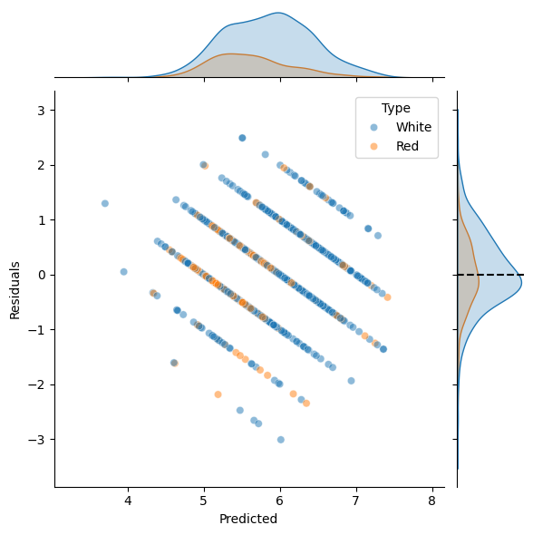

```python
plot_residuals(
    y_test.to_numpy(),
    best_record["y_pred"],
    X_test["red"].to_numpy(),
)
```

```python
test_pred_full = best_record["model"].predict(normed_X_test).ravel()

mse, rmse, mae, r2, acc1 = cm(y_test, test_pred_full)

test_prediction_summary = {
    "mse": mse,
    "rmse": rmse,
    "mae": mae,
    "r2": r2,
    "acc1": acc1,
}

test_prediction_summary
```

```
{'mse': 0.46838255988070066,
 'rmse': 0.6843848039522069,
 'mae': 0.5227579234876367,
 'r2': 0.36178143863386425,
 'acc1': 0.9623076923076923}
```

```python
first_10_predictions = pd.DataFrame(
    {
        "actual_quality": y_test.reset_index(drop=True).tail(10),
        "predicted_quality": test_pred_full[:10],
        "predicted_quality_rounded": np.round(test_pred_full[:10]),
    }
)

first_10_predictions
```

|  | actual_quality | predicted_quality | predicted_quality_rounded |
| --- | --- | --- | --- |
| 1290 | 6 | 5.514759 | 6.0 |
| 1291 | 7 | 5.433765 | 5.0 |
| 1292 | 5 | 7.031010 | 7.0 |
| 1293 | 6 | 5.624657 | 6.0 |
| 1294 | 6 | 5.810999 | 6.0 |
| 1295 | 5 | 6.376048 | 6.0 |
| 1296 | 6 | 5.166500 | 5.0 |
| 1297 | 6 | 5.750383 | 6.0 |
| 1298 | 7 | 7.035161 | 7.0 |
| 1299 | 6 | 6.245663 | 6.0 |

```python
test_pred_full = best_record["model"].predict(normed_X_test).ravel()

mse, rmse, mae, r2, acc1 = cm(y_test, test_pred_full)

print(f"MSE: {mse:.6f}")
print(f"RMSE: {rmse:.6f}")
print(f"MAE: {mae:.6f}")
print(f"R2: {r2:.6f}")
print(f"Accuracy (+/- 1 quality point): {acc1:.6f}")
```

```
MSE: 0.468383
RMSE: 0.684385
MAE: 0.522758
R2: 0.361781
Accuracy (+/- 1 quality point): 0.962308
```

```python
raw_input = "10.5;0.26;0.47;1.9;0.078;6;24;0.9976;3.18;1.04;10.9;7"

custom_red_flag = 1  # 0 = white wine, 1 = red wine

values = [float(x) for x in raw_input.split(";")]

custom_input = {
    "fixed acidity": values[0],
    "volatile acidity": values[1],
    "citric acid": values[2],
    "residual sugar": values[3],
    "chlorides": values[4],
    "free sulfur dioxide": values[5],
    "total sulfur dioxide": values[6],
    "density": values[7],
    "pH": values[8],
    "sulphates": values[9],
    "alcohol": values[10],
    "red": custom_red_flag,
}

custom_actual_quality = values[11]

custom_input, custom_actual_quality
```

```
({'fixed acidity': 10.5,
  'volatile acidity': 0.26,
  'citric acid': 0.47,
  'residual sugar': 1.9,
  'chlorides': 0.078,
  'free sulfur dioxide': 6.0,
  'total sulfur dioxide': 24.0,
  'density': 0.9976,
  'pH': 3.18,
  'sulphates': 1.04,
  'alcohol': 10.9,
  'red': 1},
 7.0)
```

```python
custom_df = pd.DataFrame([custom_input], columns=feature_names)
custom_cont = custom_df.iloc[:, :-1]
custom_cat = custom_df.iloc[:, -1:].values
custom_cont_norm = scaler.transform(custom_cont)
custom_normed = np.hstack([custom_cont_norm, custom_cat])

custom_pred = best_record["model"].predict(custom_normed).ravel()[0]
custom_pred_rounded = np.round(custom_pred)

custom_result = pd.DataFrame(
    {
        "actual_quality": [custom_actual_quality],
        "predicted_quality": [custom_pred],
        "predicted_quality_rounded": [custom_pred_rounded],
        "absolute_error": [abs(custom_pred - custom_actual_quality)],
    }
)

custom_result
```

[output not shown]